# Efficient Classification with Depthwise Separable Convolutions

### **Obiectiv**

Clasificarea imaginilor din *Fashion-MNIST* (28x28, alb-negru) in **10 clase** folosind arhitectura **MobileNetV2**, optimizata pentru eficienta pe dispozitive mobile si embedded.

### **De ce MobileNetV2**

Modelul foloseste **inverted residuals** si **depthwise separable convolutions**, reducand semnificativ costul de calcul si numarul de parametri comparativ cu CNN-urile standard.  
Este o alegere potrivita pentru modele **usoare**, cu **viteza mare de inferenta** si **consum redus de memorie**.

### **Metrice urmarite**

- **Accuracy** si **F1 macro** pe setul de test
- **Numar de parametri** ai modelului
- **Timp mediu per epoca**

### **Setari pentru modelul de baza (baseline)**

- **Rezolutie de intrare:** 96x96 pixeli
- **Ponderi initiale:** preantrenate pe *ImageNet*
- **Augmentari usoare:** aplicate la pasul 3
- **Divizare date:** stratificata (train 54k / val 6k / test 10k)
- **Optimizator:** Adam, LR initial = 1e-3

### **Scop general**

Obtinerea unui model **rapid si compact**, cu un **compromis echilibrat intre viteza si acuratete**, demonstrand avantajele arhitecturii *MobileNetV2* pentru clasificarea imaginilor *Fashion-MNIST*.

## 1. Importuri, seed, versiuni

```python
import os, random, numpy as np, tensorflow as tf
from tensorflow import keras        # API high-level din TensorFlow pentru modele si straturi
from tensorflow.keras import layers # submodul Keras pentru definirea straturilor de retea

# Reproductibilitate
SEED = 42
os.environ["PYTHONHASHSEED"] = "42"
random.seed(SEED); np.random.seed(SEED); tf.random.set_seed(SEED)

# Alocare dinamica memorie GPU
for gpu in tf.config.list_physical_devices("GPU"):
    try:
        tf.config.experimental.set_memory_growth(gpu, True)
    except Exception as e:
        print("Mem growth not set:", e)

# Montam pe Drive
from google.colab import drive
drive.mount('/content/drive', force_remount=False)

# Directoare output
OUT_DIR = "/content/drive/MyDrive/efficient-mnv2"
os.makedirs(OUT_DIR, exist_ok=True)
ckpt_path = os.path.join(OUT_DIR, "mnv2_baseline.keras")

print("TensorFlow:", tf.__version__)
print("GPU devices:", tf.config.list_physical_devices("GPU"))
print("Checkpoint path:", ckpt_path)
```

```
TensorFlow: 2.19.0
GPU devices: [PhysicalDevice(name='/physical_device:GPU:0', device_type='GPU')]
Checkpoint path: /content/drive/MyDrive/efficient-mnv2/mnv2_baseline.keras
```

## 2. Incarcare dataset, clase, normalizare si split stratificat

```python
from tensorflow.keras.datasets import fashion_mnist
from sklearn.model_selection import train_test_split
import numpy as np, matplotlib.pyplot as plt, collections

# Incarcare
(x_train, y_train), (x_test, y_test) = fashion_mnist.load_data()

# Clasele standard Keras
classes = ["T-shirt/top","Trouser","Pullover","Dress","Coat",
           "Sandal","Shirt","Sneaker","Bag","Ankle boot"]

# Normalizare de la [0-255] (uint8) la [0-1] (float32)
x_train = x_train.astype("float32") / 255.0
x_test = x_test.astype("float32") / 255.0

# Split stratificat validare 10%
VAL_FRAC = 0.1
x_train, x_val, y_train, y_val = train_test_split(
    x_train, y_train, test_size=VAL_FRAC, random_state=SEED, stratify=y_train)

print("Train:", x_train.shape, y_train.shape)
print("Valid:", x_val.shape,   y_val.shape)
print("Test: ", x_test.shape,  y_test.shape)
```

```
Train: (54000, 28, 28) (54000,)
Valid: (6000, 28, 28) (6000,)
Test:  (10000, 28, 28) (10000,)
```

```
--- Label counts ---
Train: [5400, 5400, 5400, 5400, 5400, 5400, 5400, 5400, 5400, 5400]
Valid: [600, 600, 600, 600, 600, 600, 600, 600, 600, 600]
Test:  [1000, 1000, 1000, 1000, 1000, 1000, 1000, 1000, 1000, 1000]
```

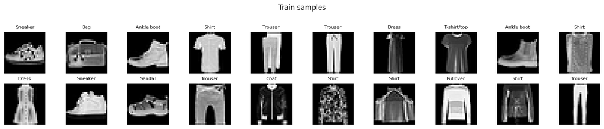

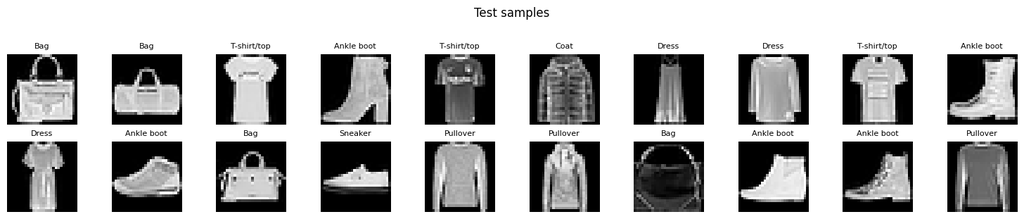

```python
# Returneaza numarul de exemple din fiecare clasa
def label_counts(y):
    c = collections.Counter(y.tolist())
    return [c[i] for i in range(10)]

print("--- Label counts ---")
print("Train:", label_counts(y_train))
print("Valid:", label_counts(y_val))
print("Test: ", label_counts(y_test))

def show_images(imgs, labels, title=None, n_cols=10, n_rows=2):
    # Creare subset aleator de imagini
    idxs = np.random.choice(len(imgs), n_cols*n_rows, replace=False)
    plt.figure(figsize=(n_cols*1.5, n_rows*1.5))

    # Grila subploturi (2x10)
    for i, idx in enumerate(idxs):
        plt.subplot(n_rows, n_cols, i+1)
        plt.imshow(imgs[idx], cmap="gray")
        plt.title(classes[int(labels[idx])], fontsize=8)
        plt.axis("off")
    if title: plt.suptitle(title, y=1.02)
    plt.tight_layout()
    plt.show()

show_images(x_train, y_train, title="Train samples")
show_images(x_test, y_test, title="Test samples")
```

## 3. Pipeline `tf.data` pentru MobileNetV2

```python
from tensorflow.keras.applications.mobilenet_v2 import preprocess_input

AUTOTUNE = tf.data.AUTOTUNE # optimizare paralelizare si prefetch
IMG_SIZE = 96               # rezolutie imagini
BATCH_SIZE = 128            # numarul de imagini / pas antrenare

# Conversie la RGB si redimensionare
def preprocess_no_scale(x, y):
    x = tf.expand_dims(x, -1)                    # (28, 28, 1)
    x = tf.image.grayscale_to_rgb(x)             # (28, 28, 3)
    x = tf.image.resize(x, (IMG_SIZE, IMG_SIZE)) # (96, 96, 3)
    return x, y

# Scalare pentru MobileNetV2
def scale_for_mobilenet(x, y):
    x = x * 255.0           # (0, 255)
    x = preprocess_input(x) # scaleaza la [-1, 1] pentru ImageNet
    return x, y

# Strat de augmentare (aplicat doar pe train)
data_augmentation = keras.Sequential([
    layers.RandomFlip("horizontal", seed=SEED),
    layers.RandomTranslation(0.05, 0.05, seed=SEED),
    layers.RandomRotation(0.05, seed=SEED),
    layers.RandomZoom(0.05, seed=SEED),
    layers.RandomContrast(0.05, seed=SEED),
], name="aug")

def make_ds(x, y, train=False):
    # Creare obiect pereche (imagine, eticheta)
    ds = tf.data.Dataset.from_tensor_slices((x, y))
    # Randomizare set de antrenare
    if train:
        ds = ds.shuffle(8192, seed=SEED)
    # Aplica functia de preprocesare pentru fiecare imagine
    ds = ds.map(preprocess_no_scale, num_parallel_calls=AUTOTUNE)
    # Aplica augmentari doar pe setul de antrenare
    if train:
      ds = ds.map(lambda xi, yi: (data_augmentation(xi, training=True), yi),
                  num_parallel_calls=AUTOTUNE)
    # Scalare imagini in [-1,1]
    ds = ds.map(scale_for_mobilenet, num_parallel_calls=AUTOTUNE)
    # Creare batch-uri si pregatire prefetch
    ds = ds.batch(BATCH_SIZE).prefetch(AUTOTUNE)
    return ds

train_ds = make_ds(x_train, y_train, train=True)
val_ds   = make_ds(x_val,   y_val)
test_ds  = make_ds(x_test,  y_test)

# Verificare
imgs, labels = next(iter(train_ds))
print("Batch:", imgs.shape, labels.shape)
print("Value range:", float(tf.reduce_min(imgs)), float(tf.reduce_max(imgs)))
```

```
Batch: (128, 96, 96, 3) (128,)
Value range: -1.0 1.0429837703704834
```

### 3.1. Vizualizare rapida mostre augmentate

[figure not shown]

```python
def show_batch(ds, classes, n=10):
    imgs, labels = next(iter(ds))
    plt.figure(figsize=(12, 6))
    for i in range(n):
        plt.subplot(2, 5, i + 1)
        arr = imgs[i].numpy()
        arr = (arr + 1.0) / 2.0 # inapoi in [0,1] pentru afisare
        arr = np.clip(arr, 0.0, 1.0)
        plt.imshow(arr)
        plt.title(classes[int(labels[i])], fontsize=8)
        plt.axis("off")
    plt.tight_layout()
    plt.show()

show_batch(train_ds, classes)
```

## 4. Model MobileNetV2 baseline si antrenare

### 4.1. Construire model

```python
ALPHA = 1.0      # factor de latime (numarul de canale)
DROPOUT = 0.2    # dezactivare 20% unitati in timpul antrenarii
NUM_CLASSES = 10 # Fashion-MNIST are 10 clase

inputs = keras.Input(shape=(IMG_SIZE, IMG_SIZE, 3)) # imagini RGB 96x96x3

# Backbone MobileNetV2 preantrenat pe ImageNet, fara strat de clasificare
base = keras.applications.MobileNetV2(
    input_shape=(IMG_SIZE, IMG_SIZE, 3),
    include_top=False, # elimina classifierul ImageNet
    weights="imagenet",
    alpha=ALPHA
)

base.trainable = False # ingheata toate straturile din backbone

# Construim capul de clasificare
x = base(inputs)
x = layers.GlobalAveragePooling2D()(x) # reduce spatialul HxW la vector
x = layers.Dropout(DROPOUT)(x)         # regularizare
# Strat final de clasificare
outputs = layers.Dense(NUM_CLASSES, activation="softmax")(x)

model = keras.Model(inputs, outputs, name=f"mobilenetv2_a{ALPHA}_s{IMG_SIZE}")
model.summary()
```

```
Model: "mobilenetv2_a1.0_s96"
```

```
┏━━━━━━━━━━━━━━━━━━━━━━━━━━━━━━━━━┳━━━━━━━━━━━━━━━━━━━━━━━━┳━━━━━━━━━━━━━━━┓
┃ Layer (type)                    ┃ Output Shape           ┃       Param # ┃
┡━━━━━━━━━━━━━━━━━━━━━━━━━━━━━━━━━╇━━━━━━━━━━━━━━━━━━━━━━━━╇━━━━━━━━━━━━━━━┩
│ input_layer_9 (InputLayer)      │ (None, 96, 96, 3)      │             0 │
├─────────────────────────────────┼────────────────────────┼───────────────┤
│ mobilenetv2_1.00_96             │ (None, 3, 3, 1280)     │     2,257,984 │
│ (Functional)                    │                        │               │
├─────────────────────────────────┼────────────────────────┼───────────────┤
│ global_average_pooling2d_3      │ (None, 1280)           │             0 │
│ (GlobalAveragePooling2D)        │                        │               │
├─────────────────────────────────┼────────────────────────┼───────────────┤
│ dropout_3 (Dropout)             │ (None, 1280)           │             0 │
├─────────────────────────────────┼────────────────────────┼───────────────┤
│ dense_3 (Dense)                 │ (None, 10)             │        12,810 │
└─────────────────────────────────┴────────────────────────┴───────────────┘
```

```
 Total params: 2,270,794 (8.66 MB)
```

```
 Trainable params: 12,810 (50.04 KB)
```

```
 Non-trainable params: 2,257,984 (8.61 MB)
```

### 4.2. Compilare si callbacks

```python
# Rata de invatare initiala
INITIAL_LR = 1e-3

# Compilare model
model.compile(
    # ajusteaza learning rate
    optimizer=keras.optimizers.Adam(learning_rate=INITIAL_LR),
    # minimizare diferenta predictie-real
    loss="sparse_categorical_crossentropy",
    # metrica raportata
    metrics=["accuracy"]
) # Keras

# Callback-uri standard
callbacks = [
    # opreste antrenarea cand val_accuracy nu mai creste
    keras.callbacks.EarlyStopping(monitor="val_accuracy", patience=3, restore_best_weights=True),
    # reduce automat rata de invatare cand val_loss stagneaza
    keras.callbacks.ReduceLROnPlateau(monitor="val_loss", factor=0.5, patience=2, min_lr=1e-5),
    # salveaza cel mai bun model pe baza val_accuracy
    keras.callbacks.ModelCheckpoint(ckpt_path, monitor="val_accuracy", save_best_only=True)
]

print("Model compilat si callback-urile configurate.")
```

```
Model compilat si callback-urile configurate.
```

### 4.3. Antrenare model baseline (backbone inghetat)

```python
# Model complet MobileNetV2 pentru clasificarea imaginilor Fashion-MNIST
def build_baseline_model(img_size=96, alpha=1.0, dropout=0.2, num_classes=10):
    # Tensor pentru imagini RGB (96×96×3)
    inputs = keras.Input(shape=(img_size, img_size, 3))

    # Stratul de augmentare
    aug = keras.Sequential([
        layers.RandomFlip("horizontal"),
        layers.RandomTranslation(0.05, 0.05),
        layers.RandomRotation(0.05),
        layers.RandomZoom(0.05),
        layers.RandomContrast(0.05),
    ], name="aug_layer")

    # Aplicare augmentari
    x = aug(inputs, training=True)

    # Backbone MobileNetV2
    base = keras.applications.MobileNetV2(
        input_shape=(img_size, img_size, 3),
        include_top=False,  # elimina ultimul strat de clasificare
        weights="imagenet", # invatate anterior
        alpha=alpha         # factor de latime (numarul de canale)
    )
    base.trainable = False  # ingheata toate straturile

    # Adaugarea capului de clasificare
    x = base(x)
    x = layers.GlobalAveragePooling2D()(x) # vector 1280 valori medii
    x = layers.Dropout(dropout)(x)         # dezactivare 20% unitati
    outputs = layers.Dense(num_classes, activation="softmax")(x)

    model = keras.Model(inputs, outputs, name=f"mnv2_a{alpha}_s{img_size}")
    return model

# Compilare model
model = build_baseline_model(IMG_SIZE, ALPHA, DROPOUT, NUM_CLASSES)
model.compile(
    optimizer=keras.optimizers.Adam(learning_rate=INITIAL_LR),
    loss="sparse_categorical_crossentropy",
    metrics=["accuracy"]
)

# Antrenare
EPOCHS = 10
history = model.fit(
    train_ds,               # flux date augmentate si preprocesate
    validation_data=val_ds, # set validare (fara augmentare)
    epochs=EPOCHS,
    callbacks=callbacks,    # early stopping, reduce LR, salvare checkpoints
    verbose=1
)
```

```
422/422 ━━━━━━━━━━━━━━━━━━━━ 215s 490ms/step - accuracy: 0.6235 - loss: 1.1028 - val_accuracy: 0.7152 - val_loss: 0.8583 - learning_rate: 0.0010
422/422 ━━━━━━━━━━━━━━━━━━━━ 207s 491ms/step - accuracy: 0.7620 - loss: 0.6714 - val_accuracy: 0.6945 - val_loss: 0.9218 - learning_rate: 0.0010
422/422 ━━━━━━━━━━━━━━━━━━━━ 226s 536ms/step - accuracy: 0.7729 - loss: 0.6341 - val_accuracy: 0.7303 - val_loss: 0.8130 - learning_rate: 0.0010
422/422 ━━━━━━━━━━━━━━━━━━━━ 230s 545ms/step - accuracy: 0.7789 - loss: 0.6212 - val_accuracy: 0.7193 - val_loss: 0.8727 - learning_rate: 0.0010
422/422 ━━━━━━━━━━━━━━━━━━━━ 217s 514ms/step - accuracy: 0.7782 - loss: 0.6106 - val_accuracy: 0.7217 - val_loss: 0.9351 - learning_rate: 0.0010
422/422 ━━━━━━━━━━━━━━━━━━━━ 202s 478ms/step - accuracy: 0.7879 - loss: 0.5955 - val_accuracy: 0.7190 - val_loss: 0.9211 - learning_rate: 5.0000e-04
```

```python
print("Validation set:", model.evaluate(val_ds, verbose=0))
print("[loss, accuracy]")
```

```
Validation set: [0.8129560351371765, 0.7303333282470703]
```

### 4.4. Fine-tuning (deblocare partiala backbone)

```python
# Cautare strat MobileNetV2 dupa nume
base_model = None
for layer in model.layers:
    if "mobilenetv2" in layer.name.lower():
        base_model = layer
        break

if base_model is None:
    raise ValueError("Backbone MobileNetV2 nu a fost gasit in model.")

# Deblocare backbone, BatchNormalization raman inghetate
base_model.trainable = True
for l in base_model.layers:
    if isinstance(l, keras.layers.BatchNormalization):
        l.trainable = False

# Rata de invatare mai mica pentru fine-tuning
FINE_TUNE_LR = 1e-4

# Compilare model
model.compile(
    optimizer=keras.optimizers.Adam(learning_rate=FINE_TUNE_LR),
    loss="sparse_categorical_crossentropy",
    metrics=["accuracy"]
)

# Antrenare
EPOCHS_FT = 8
history_ft = model.fit(
    train_ds,               # flux date augmentate si preprocesate
    validation_data=val_ds, # set validare (fara augmentare)
    epochs=EPOCHS_FT,
    callbacks=callbacks,    # early stopping, reduce LR, salvare checkpoints
    verbose=1
)
```

```
422/422 ━━━━━━━━━━━━━━━━━━━━ 237s 531ms/step - accuracy: 0.7682 - loss: 0.6430 - val_accuracy: 0.8660 - val_loss: 0.3708 - learning_rate: 1.0000e-04
422/422 ━━━━━━━━━━━━━━━━━━━━ 221s 524ms/step - accuracy: 0.8354 - loss: 0.4532 - val_accuracy: 0.8555 - val_loss: 0.3718 - learning_rate: 1.0000e-04
422/422 ━━━━━━━━━━━━━━━━━━━━ 221s 523ms/step - accuracy: 0.8545 - loss: 0.4001 - val_accuracy: 0.8360 - val_loss: 0.4303 - learning_rate: 1.0000e-04
422/422 ━━━━━━━━━━━━━━━━━━━━ 263s 524ms/step - accuracy: 0.8718 - loss: 0.3487 - val_accuracy: 0.8740 - val_loss: 0.3367 - learning_rate: 5.0000e-05
422/422 ━━━━━━━━━━━━━━━━━━━━ 221s 524ms/step - accuracy: 0.8832 - loss: 0.3209 - val_accuracy: 0.8837 - val_loss: 0.3144 - learning_rate: 5.0000e-05
422/422 ━━━━━━━━━━━━━━━━━━━━ 220s 522ms/step - accuracy: 0.8881 - loss: 0.3064 - val_accuracy: 0.8622 - val_loss: 0.3567 - learning_rate: 5.0000e-05
422/422 ━━━━━━━━━━━━━━━━━━━━ 259s 516ms/step - accuracy: 0.8879 - loss: 0.3005 - val_accuracy: 0.8412 - val_loss: 0.4650 - learning_rate: 5.0000e-05
422/422 ━━━━━━━━━━━━━━━━━━━━ 218s 516ms/step - accuracy: 0.8991 - loss: 0.2750 - val_accuracy: 0.8503 - val_loss: 0.4604 - learning_rate: 2.5000e-05
```

```python
test_loss, test_acc = model.evaluate(test_ds, verbose=0)
print(f"Test accuracy: {test_acc:.4f}")
print(f"Test loss: {test_loss:.4f}")
```

```
Test accuracy: 0.8751
Test loss: 0.3467
```

## 5. Evaluare si diagnostic

### 5.1. Incarcare model salvat si verificare scor

```python
best_model = keras.models.load_model(ckpt_path)
best_val_loss, best_val_acc = best_model.evaluate(val_ds, verbose=0)
best_test_loss, best_test_acc = best_model.evaluate(test_ds, verbose=0)

print(f"[BEST MODEL]")
print(f"Validation accuracy: {best_val_acc:.4f}")
print(f"Validation loss: {best_val_loss:.4f}")
print(f"Test accuracy: {best_test_acc:.4f}")
print(f"Test loss: {best_test_loss:.4f}")
```

```
[BEST MODEL]
Validation accuracy: 0.8837
Validation loss: 0.3144
Test accuracy: 0.8751
Test loss: 0.3467
```

### 5.2. Curbele de antrenare (baseline + fine-tuning)

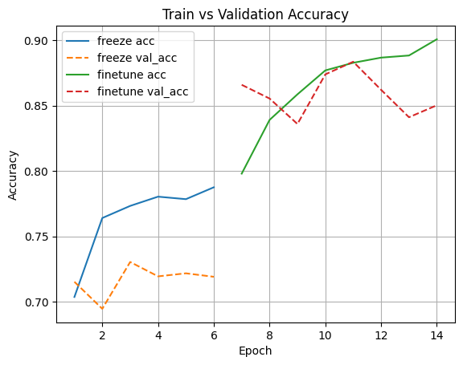

```python
def plot_histories(h_list, labels):
    import numpy as np
    accs, val_accs = [], []
    losses, val_losses = [], []
    offset = 0 # continua numerotarea epocilor intre faze

    # Extragerea valorilor inregistrate de Keras la fiecare epoca
    for h, lab in zip(h_list, labels):
        a = h.history["accuracy"]      # acuratete antrenare
        va = h.history["val_accuracy"] # acuratete validare
        l = h.history["loss"]          # eroare la antrenare
        vl = h.history["val_loss"]     # eroare la validare
        e = np.arange(offset + 1, offset + len(a) + 1) # vector de epoci
        # Desenarea linillor
        plt.plot(e, a, label=f"{lab} acc")
        plt.plot(e, va, label=f"{lab} val_acc", linestyle="--")
        offset += len(a)

    plt.xlabel("Epoch")
    plt.ylabel("Accuracy")
    plt.title("Train vs Validation Accuracy")
    plt.legend()
    plt.grid(True)
    plt.show()

plot_histories([history, history_ft], ["freeze", "finetune"])
```

**(freeze acc) - linia albastra**

- acuratetea pe setul de antrenare atunci cand doar straturile finale au fost antrenare, backbone-ul a fost inghetat
- cerestere lenta si plafonare in jur de 0.78

**(freeze val_acc) - linia portocalie**

- acuratetea pe setul de validare
- fluctueaza intre 0.69-0.73
- modelul invata bazele, dar nu generalizeaza complet

**(finetune acc) - linia verde**

- incepe dupa deblocarea backbone-ului
- creste constant pana spre 0.9
- reantrenarea straturilor convolutionale aduce imbunatatiri clare

**(finetune val_acc) - linia rosie**

### 5.3. Raport pe clase si matrice de confuzie

```
              precision    recall  f1-score   support

 T-shirt/top     0.8979    0.8440    0.8701      1000
     Trouser     0.9969    0.9760    0.9864      1000
    Pullover     0.8962    0.8720    0.8839      1000
       Dress     0.9112    0.8820    0.8963      1000
        Coat     0.7790    0.9340    0.8495      1000
      Sandal     1.0000    0.6890    0.8159      1000
       Shirt     0.7456    0.7150    0.7300      1000
     Sneaker     0.8750    0.8750    0.8750      1000
         Bag     0.8960    0.9740    0.9334      1000
  Ankle boot     0.8209    0.9900    0.8976      1000

    accuracy                         0.8751     10000
   macro avg     0.8819    0.8751    0.8738     10000
weighted avg     0.8819    0.8751    0.8738     10000
```

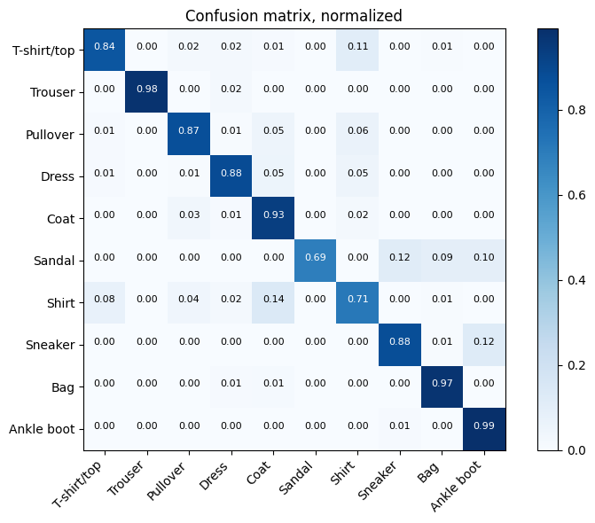

```python
from sklearn.metrics import classification_report, confusion_matrix
import numpy as np
import matplotlib.pyplot as plt

# Folosim modelul salvat ca referinta
mdl = best_model

# Colectam predictiile pe test
y_true, y_pred = [], []
# Parcurgem setul de test batch cu batch
for xb, yb in test_ds:
    probs = mdl.predict(xb, verbose=0)      # distributia de probabilitati pt fiecare clasa
    y_true.append(yb.numpy())
    y_pred.append(np.argmax(probs, axis=1)) # alege clasa cu cea mai mare probabilitate
# Concatenam toate batch-urile intr-un singur vector de etichete
y_true = np.concatenate(y_true)
y_pred = np.concatenate(y_pred)

# Raport pe clase
print(classification_report(y_true, y_pred, target_names=classes, digits=4))

# Matrice de confuzie
cm = confusion_matrix(y_true, y_pred)
cm_norm = cm / cm.sum(axis=1, keepdims=True)

plt.figure(figsize=(8, 6))
plt.imshow(cm_norm, cmap="Blues")
plt.title("Confusion matrix, normalized")
plt.xticks(np.arange(len(classes)), classes, rotation=45, ha="right")
plt.yticks(np.arange(len(classes)), classes)
plt.colorbar()
# Valori pe celule cu 2 zecimale
th = cm_norm.max() / 2.0
for i in range(len(classes)):
    for j in range(len(classes)):
        val = cm_norm[i, j]
        plt.text(j, i, f"{val:.2f}", ha="center",
                 color="white" if val > th else "black", fontsize=8)
plt.tight_layout()
plt.show()
```

## 6. Experimente antrenare model

IMG_SIZE x ALPHA, timp/epoca, params, val/test acc

```python
# Montarea Drive-ului
from google.colab import drive
drive.mount('/content/drive', force_remount=False)

import tensorflow as tf, os, numpy as np, random
from tensorflow import keras
from tensorflow.keras import layers

SEED = 42
random.seed(SEED); np.random.seed(SEED); tf.random.set_seed(SEED)

OUT_DIR = "/content/drive/MyDrive/efficient-mnv2"
ckpt_path = os.path.join(OUT_DIR, "mnv2_baseline.keras")
print("Checkpoint:", os.path.exists(ckpt_path), ckpt_path)
```

```
Checkpoint: True /content/drive/MyDrive/efficient-mnv2/mnv2_baseline.keras
```

```python
# Incarcarea modelului salvat
model = keras.models.load_model(ckpt_path)
print("Model loaded successfully.")
```

```
Model loaded successfully.
```

```python
# Reincarcarea datelor Fashion-MNIST
from tensorflow.keras.datasets import fashion_mnist
from sklearn.model_selection import train_test_split
import numpy as np, collections, matplotlib.pyplot as plt

(x_train, y_train), (x_test, y_test) = fashion_mnist.load_data()

classes = ["T-shirt/top","Trouser","Pullover","Dress","Coat",
           "Sandal","Shirt","Sneaker","Bag","Ankle boot"]

x_train = x_train.astype("float32") / 255.0
x_test  = x_test.astype("float32") / 255.0

VAL_FRAC = 0.1
x_train, x_val, y_train, y_val = train_test_split(
    x_train, y_train, test_size=VAL_FRAC, random_state=SEED, stratify=y_train)

print("Train:", x_train.shape, y_train.shape)
print("Valid:", x_val.shape, y_val.shape)
print("Test: ", x_test.shape, y_test.shape)
```

```
Train: (54000, 28, 28) (54000,)
Valid: (6000, 28, 28) (6000,)
Test:  (10000, 28, 28) (10000,)
```

```python
import time, os
import numpy as np
import pandas as pd
import tensorflow as tf
from tensorflow import keras
from tensorflow.keras import layers
from tensorflow.keras.applications.mobilenet_v2 import preprocess_input

# Configuratii test
exp_configs = [
    {"IMG_SIZE": 96,  "ALPHA": 1.0},
    {"IMG_SIZE": 128, "ALPHA": 1.0},
    {"IMG_SIZE": 128, "ALPHA": 0.75},
]

# Hiperparametri pentru CPU
WARMUP_EPOCHS = 2      # inghetat
FT_EPOCHS     = 2      # fine-tuning
LR_WARMUP     = 1e-3
LR_FT         = 1e-4
DROPOUT       = 0.2
BATCH_EXP     = 64
AUTOTUNE      = tf.data.AUTOTUNE

# Dataset pentru o rezolutie data
def make_ds_for_size(x, y, img_size, train=False):
    # Redimensionare, conversie RGB, scalare, batching
    def _pp(xi, yi):
        xi = tf.expand_dims(xi, -1)                 # (28,28,1)
        xi = tf.image.grayscale_to_rgb(xi)          # (28,28,3)
        xi = tf.image.resize(xi, (img_size, img_size))
        xi = preprocess_input(xi * 255.0)           # [-1,1] MobileNetV2
        return xi, yi
    ds = tf.data.Dataset.from_tensor_slices((x, y))
    if train:
        ds = ds.shuffle(8192, seed=SEED)
    ds = ds.map(_pp, num_parallel_calls=AUTOTUNE)
    ds = ds.batch(BATCH_EXP).prefetch(AUTOTUNE)
    return ds

# Augmentari doar in tf.data
aug_warm = keras.Sequential([
    layers.RandomFlip("horizontal", seed=SEED),
    layers.RandomTranslation(0.05, 0.05, seed=SEED),
    layers.RandomRotation(0.05, seed=SEED),
    layers.RandomZoom(0.05, seed=SEED),
    layers.RandomContrast(0.05, seed=SEED),
], name="aug_warm") # Augmentare warmup

aug_light = keras.Sequential([
    layers.RandomFlip("horizontal", seed=SEED),
    layers.RandomRotation(0.03, seed=SEED),
], name="aug_light") # Augmentare fine-tuning

# Model baseline MobileNetV2 fara augmentare interna
def build_baseline_model(img_size=96, alpha=1.0, dropout=0.2, num_classes=10):
    # Tensor pentru imagini RGB (96×96×3)
    inputs = keras.Input(shape=(img_size, img_size, 3))
    # Backbone MobileNetV2
    base = keras.applications.MobileNetV2(
        input_shape=(img_size, img_size, 3),
        include_top=False,  # elimina ultimul strat de clasificare
        weights="imagenet", # invatate anterior
        alpha=alpha         # factor de latime (numarul de canale)
    )
    base.trainable = False  # ingheata toate straturile
    x = base(inputs)
    x = layers.GlobalAveragePooling2D()(x) # vector 1280 valori medii
    x = layers.Dropout(dropout)(x)         # dezactivare 20% unitati
    outputs = layers.Dense(num_classes, activation="softmax")(x)
    return keras.Model(inputs, outputs, name=f"mnv2_a{alpha}_s{img_size}")

def run_experiment(cfg):
    img_size, alpha = cfg["IMG_SIZE"], cfg["ALPHA"]

    # Date la rezolutia ceruta
    tr_ds = make_ds_for_size(x_train, y_train, img_size, train=True)
    va_ds = make_ds_for_size(x_val,   y_val,   img_size, train=False)
    te_ds = make_ds_for_size(x_test,  y_test,  img_size, train=False)

    # Augmentare in tf.data doar pe train
    tr_warm  = tr_ds.map(lambda x,y: (aug_warm(x,  training=True), y),
                         num_parallel_calls=AUTOTUNE).prefetch(AUTOTUNE)
    tr_light = tr_ds.map(lambda x,y: (aug_light(x, training=True), y),
                         num_parallel_calls=AUTOTUNE).prefetch(AUTOTUNE)

    # Model baseline, backbone inghetat
    model = build_baseline_model(img_size=img_size, alpha=alpha, dropout=DROPOUT, num_classes=10)

    # Callbacks per-config, salveaza cel mai bun model pe val_accuracy
    ckpt_cfg = os.path.join(OUT_DIR, f"mnv2_a{alpha}_s{img_size}.keras")
    cbs = [
        keras.callbacks.EarlyStopping(monitor="val_accuracy", patience=2, restore_best_weights=True),
        keras.callbacks.ReduceLROnPlateau(monitor="val_loss", factor=0.5, patience=1, min_lr=1e-5),
        keras.callbacks.ModelCheckpoint(ckpt_cfg, monitor="val_accuracy", save_best_only=True),
    ]

    # Faza 1 - freeze: doar capul se antreneaza, LR mai mare
    model.compile(optimizer=keras.optimizers.Adam(LR_WARMUP),
                  loss="sparse_categorical_crossentropy", metrics=["accuracy"])
    t0 = time.time()
    h1 = model.fit(tr_warm, validation_data=va_ds, epochs=WARMUP_EPOCHS, callbacks=cbs, verbose=1)

    # Faza 2 - fine-tune: backbone deblocat, BatchNorm ramane inghetat, LR mic
    base = None
    for layer in model.layers:
        if "mobilenetv2" in layer.name.lower():
            base = layer; break
    base.trainable = True
    for l in base.layers:
        if isinstance(l, keras.layers.BatchNormalization):
            l.trainable = False

    model.compile(optimizer=keras.optimizers.Adam(LR_FT),
                  loss="sparse_categorical_crossentropy", metrics=["accuracy"])
    h2 = model.fit(tr_light, validation_data=va_ds, epochs=FT_EPOCHS, callbacks=cbs, verbose=1)
    t1 = time.time()

    # Evaluare pe test
    test_loss, test_acc = model.evaluate(te_ds, verbose=0)
    # Timpi si epoci
    n_ep = len(h1.history["accuracy"]) + len(h2.history["accuracy"])
    sec_per_epoch = (t1 - t0) / max(n_ep, 1)

    return {
        "IMG_SIZE": img_size,
        "ALPHA": alpha,
        "params": model.count_params(),
        "best_val_acc": float(max(h1.history["val_accuracy"] + h2.history["val_accuracy"])),
        "test_acc": float(test_acc),
        "sec_per_epoch": float(sec_per_epoch),
        "epochs_run": n_ep,
    }

# Ruleaza configurarile
results = []
for cfg in exp_configs:
    print(f"\n--- Run ---")
    print(f"IMG_SIZE = {cfg['IMG_SIZE']} | ALPHA = {cfg['ALPHA']}")
    res = run_experiment(cfg)
    results.append(res)
    print(res)

# Tabel sumar
df = pd.DataFrame(results).sort_values(by=["test_acc","params"], ascending=[False, True])
print("\nSummary:")
print(df.to_string(index=False))
```

```
--- Run ---
IMG_SIZE = 96 | ALPHA = 1.0
844/844 ━━━━━━━━━━━━━━━━━━━━ 694s 814ms/step - accuracy: 0.6631 - loss: 0.9951 - val_accuracy: 0.7615 - val_loss: 0.6546 - learning_rate: 0.0010
844/844 ━━━━━━━━━━━━━━━━━━━━ 643s 760ms/step - accuracy: 0.7890 - loss: 0.5921 - val_accuracy: 0.7622 - val_loss: 0.6875 - learning_rate: 0.0010
844/844 ━━━━━━━━━━━━━━━━━━━━ 1411s 2s/step - accuracy: 0.8606 - loss: 0.3823 - val_accuracy: 0.9078 - val_loss: 0.2607 - learning_rate: 1.0000e-04
844/844 ━━━━━━━━━━━━━━━━━━━━ 1395s 2s/step - accuracy: 0.9171 - loss: 0.2271 - val_accuracy: 0.9193 - val_loss: 0.2168 - learning_rate: 1.0000e-04
{'IMG_SIZE': 96, 'ALPHA': 1.0, 'params': 2270794, 'best_val_acc': 0.9193333387374878, 'test_acc': 0.9190999865531921, 'sec_per_epoch': 1035.7415756583214, 'epochs_run': 4}

--- Run ---
IMG_SIZE = 128 | ALPHA = 1.0
Downloading data from https://storage.googleapis.com/tensorflow/keras-applications/mobilenet_v2/mobilenet_v2_weights_tf_dim_ordering_tf_kernels_1.0_128_no_top.h5
9406464/9406464 ━━━━━━━━━━━━━━━━━━━━ 0s 0us/step
844/844 ━━━━━━━━━━━━━━━━━━━━ 1189s 1s/step - accuracy: 0.6612 - loss: 0.9961 - val_accuracy: 0.6885 - val_loss: 0.8716 - learning_rate: 0.0010
844/844 ━━━━━━━━━━━━━━━━━━━━ 1180s 1s/step - accuracy: 0.7830 - loss: 0.6091 - val_accuracy: 0.7147 - val_loss: 0.8322 - learning_rate: 0.0010
844/844 ━━━━━━━━━━━━━━━━━━━━ 2619s 3s/step - accuracy: 0.8576 - loss: 0.3940 - val_accuracy: 0.9177 - val_loss: 0.2271 - learning_rate: 1.0000e-04
844/844 ━━━━━━━━━━━━━━━━━━━━ 2544s 3s/step - accuracy: 0.9161 - loss: 0.2318 - val_accuracy: 0.9195 - val_loss: 0.2261 - learning_rate: 1.0000e-04
{'IMG_SIZE': 128, 'ALPHA': 1.0, 'params': 2270794, 'best_val_acc': 0.9194999933242798, 'test_acc': 0.9153000116348267, 'sec_per_epoch': 1883.1503722071648, 'epochs_run': 4}

--- Run ---
IMG_SIZE = 128 | ALPHA = 0.75
Downloading data from https://storage.googleapis.com/tensorflow/keras-applications/mobilenet_v2/mobilenet_v2_weights_tf_dim_ordering_tf_kernels_0.75_128_no_top.h5
5903360/5903360 ━━━━━━━━━━━━━━━━━━━━ 0s 0us/step
844/844 ━━━━━━━━━━━━━━━━━━━━ 1014s 1s/step - accuracy: 0.6686 - loss: 0.9639 - val_accuracy: 0.7580 - val_loss: 0.7025 - learning_rate: 0.0010
844/844 ━━━━━━━━━━━━━━━━━━━━ 1007s 1s/step - accuracy: 0.7904 - loss: 0.5888 - val_accuracy: 0.7563 - val_loss: 0.7195 - learning_rate: 0.0010
844/844 ━━━━━━━━━━━━━━━━━━━━ 2007s 2s/step - accuracy: 0.8625 - loss: 0.3773 - val_accuracy: 0.9085 - val_loss: 0.2471 - learning_rate: 1.0000e-04
844/844 ━━━━━━━━━━━━━━━━━━━━ 2169s 3s/step - accuracy: 0.9146 - loss: 0.2359 - val_accuracy: 0.9202 - val_loss: 0.2120 - learning_rate: 1.0000e-04
{'IMG_SIZE': 128, 'ALPHA': 0.75, 'params': 1394874, 'best_val_acc': 0.9201666712760925, 'test_acc': 0.9132000207901001, 'sec_per_epoch': 1549.4524006843567, 'epochs_run': 4}

Summary:
 IMG_SIZE  ALPHA  params  best_val_acc  test_acc  sec_per_epoch  epochs_run
       96   1.00 2270794      0.919333    0.9191    1035.741576           4
      128   1.00 2270794      0.919500    0.9153    1883.150372           4
      128   0.75 1394874      0.920167    0.9132    1549.452401           4
```

## 7. Salvare model si analiza rezultate

```python
# Salvare model final
best_model_path = os.path.join(OUT_DIR, "mnv2_final_best.keras")
model.save(best_model_path)
print("Model saved successfully at:", best_model_path)
```

```
Model saved successfully at: /content/drive/MyDrive/efficient-mnv2/mnv2_final_best.keras
```

```python
from tensorflow.keras.models import load_model

# Incarcare model salvat din Drive
model = load_model(best_model_path)
print("Model loaded successfully.")
```

```
Model loaded successfully.
```

### 7.1. Afisare imagine originala (bruta din dataset)

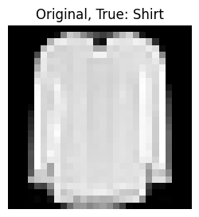

```python
import matplotlib.pyplot as plt
import numpy as np

# Alegem o imagine aleatoare din setul de test
idx = np.random.randint(0, len(x_test))
img = x_test[idx]
true_label = classes[int(y_test[idx])]

plt.figure(figsize=(3, 3))
plt.imshow(img, cmap="gray")
plt.title(f"Original, True: {true_label}")
plt.axis("off")
plt.show()
```

### 7.2. Preprocesare si predictie pentru o singura imagine

```python
import tensorflow as tf
from tensorflow.keras.applications.mobilenet_v2 import preprocess_input

# Dimensiunea de intrare a modelului incarcat
IMG_SIZE = int(model.input_shape[1])

# Preprocesare identica cu antrenarea
img_rgb = tf.image.grayscale_to_rgb(tf.expand_dims(img, -1)) # 1 -> 3 canale
img_resized = tf.image.resize(img_rgb, (IMG_SIZE, IMG_SIZE)) # redimensionare
img_ready = preprocess_input(img_resized * 255.0)            # scalare [-1,1]

# Predictie
probs = model.predict(tf.expand_dims(img_ready, 0), verbose=0)[0]
pred_idx = int(np.argmax(probs))
pred_label = classes[pred_idx]

print("Predicted:", pred_label)
print("Actual:", true_label)
```

```
Predicted: Shirt
Actual: Shirt
```

### 7.3. Imagine originala vs. input-ul efectiv pentru model

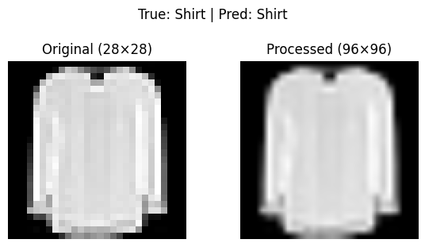

```python
# Reconversie pentru afisare umana (din [-1,1] in [0,1])
arr = (img_ready + 1.0) / 2.0
arr = np.clip(arr.numpy(), 0.0, 1.0)

plt.figure(figsize=(6, 3))
plt.subplot(1, 2, 1)
plt.imshow(img, cmap="gray", interpolation="nearest")
plt.title("Original (28×28)")
plt.axis("off")

plt.subplot(1, 2, 2)
plt.imshow(arr)
plt.title(f"Processed ({IMG_SIZE}×{IMG_SIZE})")
plt.axis("off")

plt.suptitle(f"True: {true_label} | Pred: {pred_label}", y=1.02)
plt.tight_layout()
plt.show()
```

### 7.4. Grid cu 10 imagini de test si predictiile lor

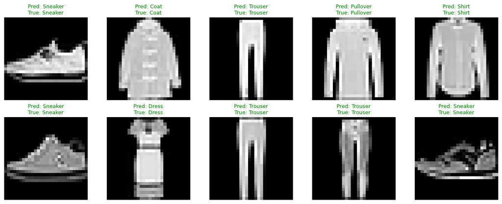

```python
def show_predictions_grid(model, x_test, y_test, classes, img_size=IMG_SIZE, n=10, n_rows=2, n_cols=5):
    from tensorflow.keras.applications.mobilenet_v2 import preprocess_input

    idxs = np.random.choice(len(x_test), n, replace=False)
    plt.figure(figsize=(n_cols * 2.5, n_rows * 2.5))

    for i, idxx in enumerate(idxs):
        im = x_test[idxx]
        true_lab = classes[int(y_test[idxx])]

        # Preprocesare identica cu antrenarea
        im_rgb = tf.image.grayscale_to_rgb(tf.expand_dims(im, -1))
        im_res = tf.image.resize(im_rgb, (img_size, img_size))
        im_ready = preprocess_input(im_res * 255.0)

        p = model.predict(tf.expand_dims(im_ready, 0), verbose=0)[0]
        pred_lab = classes[int(np.argmax(p))]

        plt.subplot(n_rows, n_cols, i + 1)
        plt.imshow(im, cmap="gray")
        plt.axis("off")
        ok = (pred_lab == true_lab)
        plt.title(f"Pred: {pred_lab}\nTrue: {true_lab}", fontsize=9, color=("green" if ok else "red"))

    plt.tight_layout()
    plt.show()

# Rulare
show_predictions_grid(model, x_test, y_test, classes)
```

## 8. Rezultate si concluzii

- **Arhitectura:** *MobileNetV2* preantrenat, cu **cap de clasificare nou** si **depthwise separable convolutions**
- **Antrenare in 2 faze:** **warmup** cu *backbone inghetat*, apoi **fine-tuning** cu *BatchNorm* inghetat si **rata de invatare mica (LR)**
- **Acuratete finala pe test:**
  - ~**0.875** pentru modelul de baza
  - ~**0.919** pentru configuratia optima din experimente
- **Experimente (IMG_SIZE x α):**
  - **96 x 96, α=1.0, 2.27M param, test_acc ≈ 0.919**, timp pe epoca scazut
  - **128 x 128, α=1.0, 2.27M param, test_acc ≈ 0.915**, timp pe epoca mai mare
  - **128 x 128, α=0.75, 1.39M param, test_acc ≈ 0.913**, parametri redusi semnificativ
- **Concluzie:** configuratia **96 x 96, α=1.0** ofera **cel mai bun raport intre viteza, dimensiune si precizie** pe datasetul *Fashion-MNIST*
- **Analiza erorilor:** confuzii frecvente intre:
  - **Shirt** cu **T-shirt** si **Coat**
  - **Sandal** cu **Sneaker** si **Ankle boot**

## 9. Export proiect in format html

```python
from google.colab import files, drive
drive.mount('/content/drive')
```

```python
%%shell
jupyter nbconvert --to html '/content/drive/MyDrive/Colab Notebooks/SACCM_Proiect/CosminM_Proiect.ipynb' --output='/content/CosminM_Proiect.html'
```

```python
files.download('CosminM_Proiect.html')
```